# Reproducible Research: Peer Assessment 1

Analysis of activity monitoring data for Coursera Reproducible Research course (Course Project 1).

```r
library(knitr)
library(dplyr)
library(lubridate)
library(lattice)
```

```r
opts_chunk$set(echo = TRUE)

# ensure numbers formatted in inline text are not in scientific notation
options(scipen = 999)
```

## Loading and preprocessing the data

Note that this step assumes that the activity.csv file has been unzipped and is located in the working directory.

```r
activity <- read.csv("activity.csv")
```

## What is mean total number of steps taken per day?

```r
by_day <- activity |>
  group_by(date) |>
  summarize(total = sum(steps, na.rm = TRUE))

by_day
```

```
## # A tibble: 61 × 2
##    date       total
##    <chr>      <int>
##  1 2012-10-01     0
##  2 2012-10-02   126
##  3 2012-10-03 11352
##  4 2012-10-04 12116
##  5 2012-10-05 13294
##  6 2012-10-06 15420
##  7 2012-10-07 11015
##  8 2012-10-08     0
##  9 2012-10-09 12811
## 10 2012-10-10  9900
## # ℹ 51 more rows
```

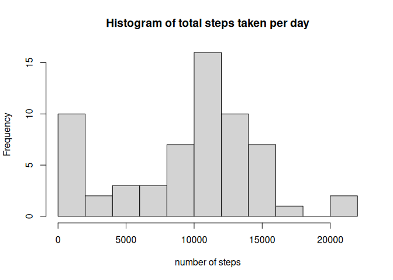

```r
hist(by_day$total,
     breaks = 15, # increase number of bins; default doesn't give a good sense of the pattern
     main = "Histogram of total steps taken per day",
     xlab = "number of steps")
```

```r
mean_steps <- mean(by_day$total)
median_steps <- median(by_day$total)
```

With missing values ignored, the mean number of steps taken per day was 9354 and the median was 10395. (All means in text are rounded to whole numbers.)

## What is the average daily activity pattern?

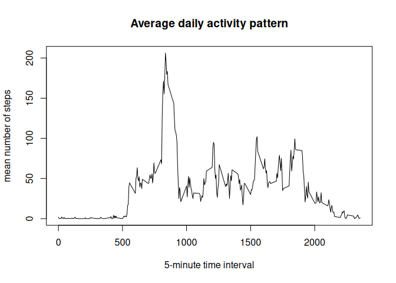

```r
by_interval <- activity |>
  group_by(interval) |>
  summarize(mean_steps = mean(steps, na.rm = TRUE))

with(by_interval, plot(interval, mean_steps,
                       type = "l",
                       xlab = "5-minute time interval",
                       ylab = "mean number of steps",
                       main = "Average daily activity pattern"))
```

```r
max_interval <- by_interval[by_interval$mean_steps == max(by_interval$mean_steps, na.rm = TRUE), ]
```

The 5-minute interval with the highest average number of steps was interval 835, with an average 206 steps taken.

## Imputing missing values

```r
n_missing <- sum(is.na(activity$steps))
```

There are 2304 missing values in the dataset.

Missing values will be imputed using the mean value for the same interval.

First, add a column to the dataset showing the mean number of steps for each interval. Note that this works because the intervals repeat and are always in the same order.

```r
activity$interval_mean <- by_interval$mean_steps
```

Next, create a steps_imputed column containing the actual steps for that interval if they were recorded, and the mean otherwise. Finally, remove the interval_mean column.

```r
activity <- activity |>
  mutate(steps_imputed = if_else(is.na(steps),
                                 interval_mean,
                                 steps)) |>
  select(-interval_mean)
```

Summarize the data by day, as above, but now using the imputed data.

```r
by_day_imputed <- activity |>
  group_by(date) |>
  summarize(total = sum(steps_imputed, na.rm = TRUE))
```

Make the histogram.

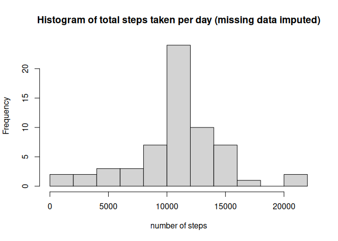

```r
hist(by_day_imputed$total,
     breaks = 15,
     main = "Histogram of total steps taken per day (missing data imputed)",
     xlab = "number of steps")
```

Compared to the previous histogram without imputed data, this version lacks the peak in the smallest bin (0-2000 steps) and has a higher peak in the center (10000-12000 steps).

```r
mean_steps_imputed <- mean(by_day_imputed$total)
median_steps_imputed <- median(by_day_imputed$total)
```

## Are there differences in activity patterns between weekdays and weekends?

Convert the date column to a date format, then use weekdays() to find the day of the week. Then make a new variable indicating whether the date is a weekday or a weekend day.

```r
activity <- activity |>
  mutate(date = ymd(date),
         weekday = if_else(weekdays(date) %in% c("Saturday", "Sunday"),
                           "weekend",
                           "weekday"),
         weekday = as.factor(weekday))
```

```r
by_interval_wkday <- activity |>
  group_by(interval, weekday) |>
  summarize(mean_steps = mean(steps_imputed))
```

Make graph using lattice system:

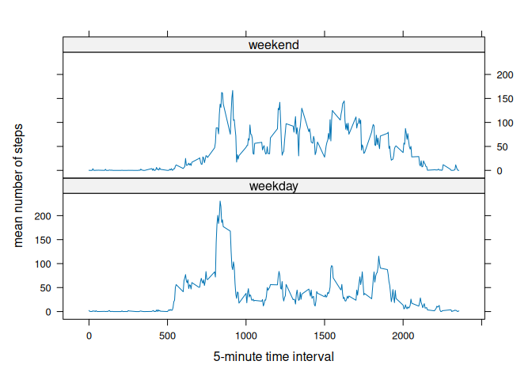

```r
xyplot(mean_steps ~ interval | weekday,
       data = by_interval_wkday,
       type = "l",
       layout = c(1, 2),
       xlab = "5-minute time interval",
       ylab = "mean number of steps")
```